# Rester ou partir

roua blel

03/05/2022

## Introduction

Aprés la révolution le nombre des migrants de la Tunisie ne cesse à croitre surtout chez les jeunes ,cette enquête essaye d’analyser les causes de migration. elle envisage toutes les tranches d’âge. Les réponses ont été enregistrés au cours de la periode du 22 mars 2022 jusqu’à 31 mars 2022. Ce projet est realisé par Roua Blel , et supervisé par Mr. Ghazi Bel Mufti.

## Analyse des réponses :

*Chargement des paquêts*

```r
library("readxl")
library(FactoMineR)
library(ggplot2)
library(factoextra)
library("dplyr")
library("corrplot")
library("questionr")
```

## Chargement de la base des réponses:

```r
AD <- read_excel("C:/Users/roua blel/Downloads/AD.xlsx")

head(AD)
```

```
## # A tibble: 6 x 29
##   Horodateur     `Sexe:` `Age :` Catég~1 Dans ~2 Avez-~3 avez-~4 Envis~5 Allez~6
##   <chr>          <chr>   <chr>   <chr>   <chr>   <chr>   <chr>   <chr>   <chr>
## 1 22/13/2122 13~ Femelle 19-24 ~ étudia~ Scient~ oui     oui     Aucune~ oui
## 2 22/13/2122 14~ Mâle    19-24 ~ étudia~ Scient~ non     oui     oui     oui
## 3 22/13/2122 15~ Femelle 19-24 ~ étudia~ Scient~ oui     oui     oui     Non
## 4 22/13/2122 18~ Mâle    15-18 ~ étudia~ Scient~ oui     oui     oui     oui
## 5 22/13/2122 18~ Mâle    19-24 ~ étudia~ Scient~ oui     Non     oui     oui
## 6 22/13/2122 18~ Mâle    15-18 ~ étudia~ Scient~ oui     Non     oui     oui
## # ... with 20 more variables:
## #   `Quel est votre degré de satisfaction par rapport à la  situation de la Tunisie dans ses domaines ?  [État économique]` <dbl>,
## #   `Quel est votre degré de satisfaction par rapport à la  situation de la Tunisie dans ses domaines ?  [État politique]` <dbl>,
## #   `Quel est votre degré de satisfaction par rapport à la  situation de la Tunisie dans ses domaines ?  [État de santé]` <dbl>,
## #   `Quel est votre degré de satisfaction par rapport à la  situation de la Tunisie dans ses domaines ?  [Qualité de l’éducation]` <dbl>,
## #   `Quel est votre degré de satisfaction par rapport à la  situation de la Tunisie dans ses domaines ?  [État de securité]` <dbl>,
## #   `La "Harga" est une solution pour les jeunes, face aux problèmes de chômage et de pauvreté?` <chr>, ...
```

*Manipulation de la base des données*

[output not shown]

## Un coup d’œil sur les statistiques :

*La répartition des mâles et des femelles*

```r
AD$sexe<-factor(AD$sexe,levels=c("Femelle","Mâle"))
freq=table((AD$sexe))
freq
```

```
##
## Femelle    Mâle
##      48      30
```

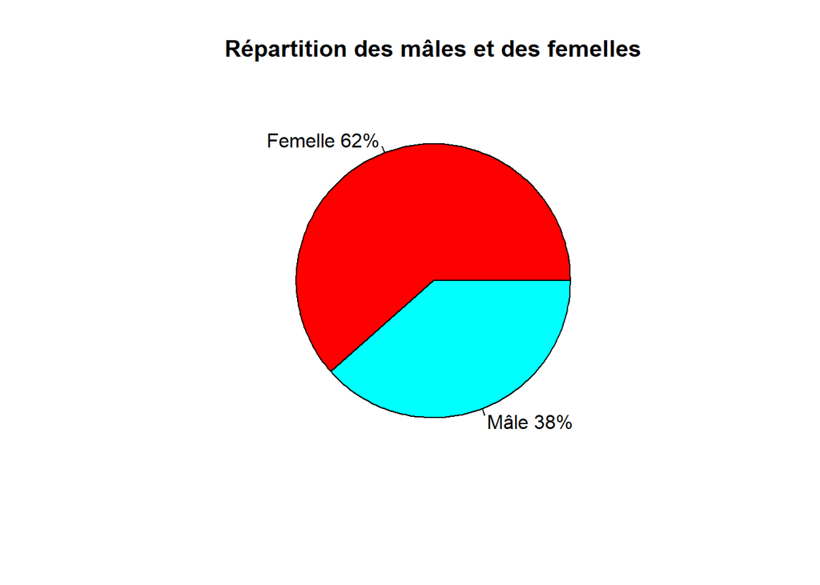

```r
pct1 <- round(freq/sum(freq)*100)
labls1 <- paste(c("Femelle","Mâle"),pct1)
labls1 <- paste(labls1,"%",sep="")
pie(freq,labels = labls1, col=rainbow(length(labls1)),main="Répartition des mâles et des femelles")
```

```r
AD$VS1<-factor(AD$VS1,c("chômeur","fonctionnaire","étudiant","cadre supérieur","retraité"))
freq2=table(AD$VS1)
freq2
```

```
##
##         chômeur   fonctionnaire        étudiant cadre supérieur        retraité
##               4               4              64               3               3
```

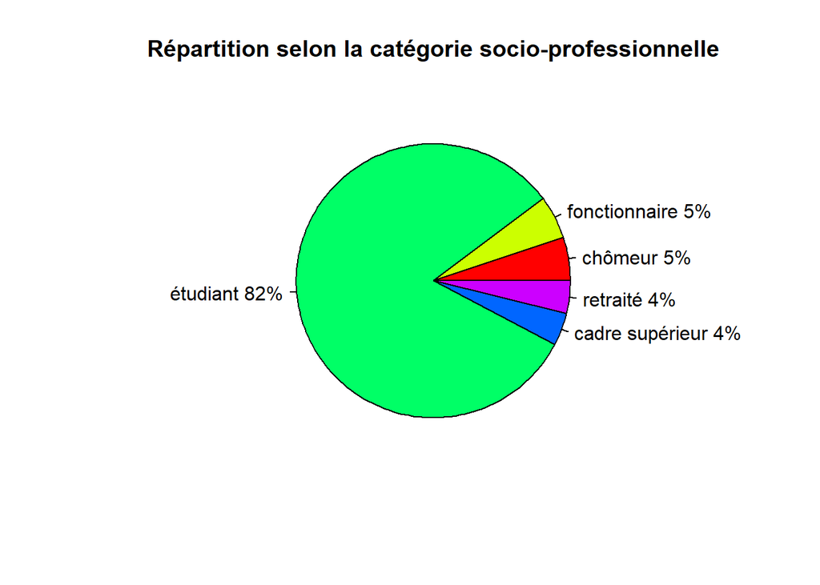

```r
pct2 <- round(freq2/sum(freq2)*100)
labls2 <- paste(c("chômeur","fonctionnaire","étudiant","cadre supérieur","retraité"), pct2)
labls2 <- paste(labls2,"%",sep="")
pie(freq2,labels = labls2,col=rainbow(5), main="Répartition selon la catégorie socio−professionnelle")
```

*La répartition des âges :*

```r
AD$age <-factor(AD$age,levels=c("15-18 ans","19-24 ans","25-34 ans","35-44 ans","45-64 ans","plus de 65 ans"))
freq3=table(AD$age)
freq3
```

```
##
##      15-18 ans      19-24 ans      25-34 ans      35-44 ans      45-64 ans
##             32             34              3              2              3
## plus de 65 ans
##              3
```

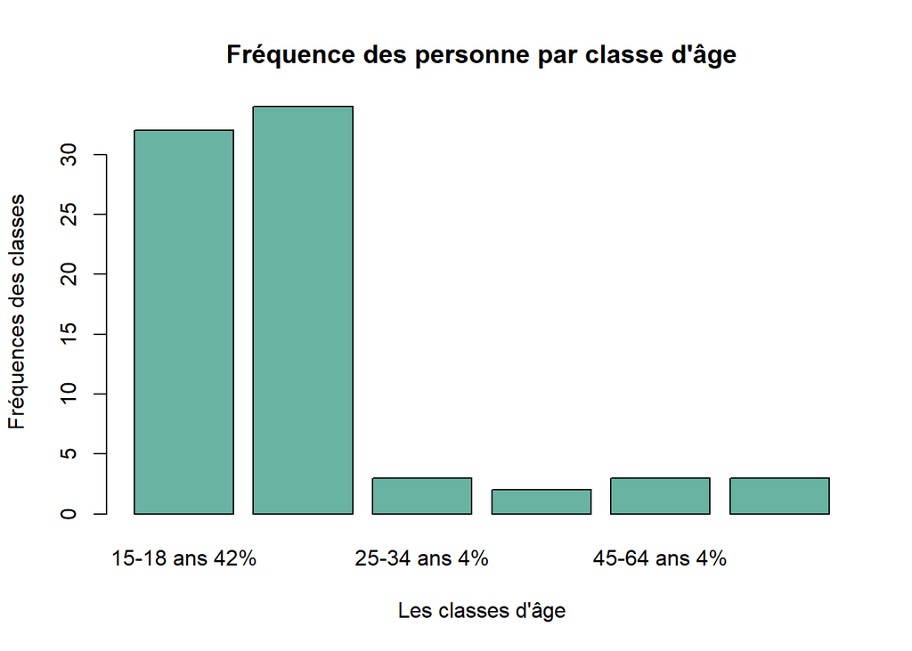

```r
pct3 <- round(freq3/sum(freq3)*100)
lbls3 <- paste(c("15-18 ans","19-24 ans","25-34 ans","35-44 ans","45-64 ans","plus de 65 ans"), pct3)
lbls3 <- paste(lbls3,"%",sep="")
barplot(freq3,names.arg=lbls3,col="#69b3a2",
main="Fréquence des personne par classe d'âge",
xlab="Les classes d'âge",
ylab="Fréquences des classes")
```

```r
AD$VS2<-factor(AD$VS2,levels=c("Scientifique","Littéraire"))
freq2=table(AD$VS2)
freq2
```

```
##
## Scientifique   Littéraire
##           67           10
```

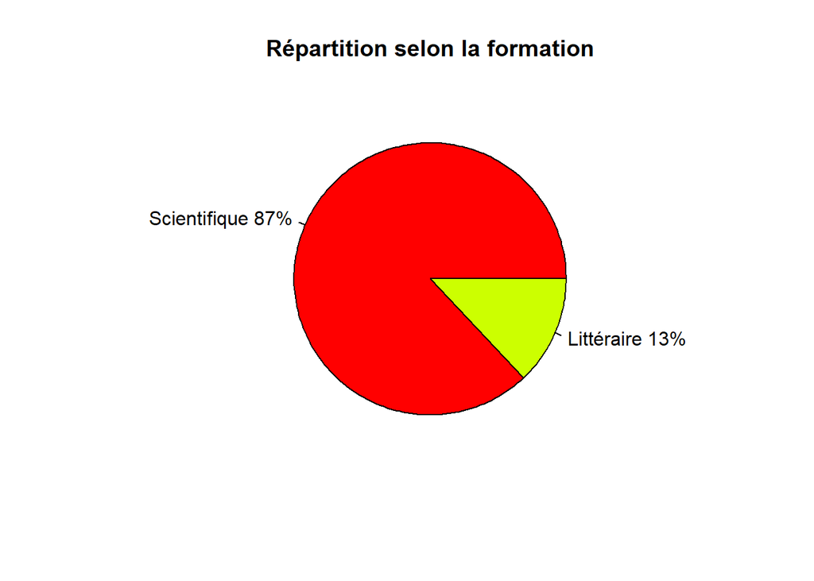

```r
pct2 <- round(freq2/sum(freq2)*100)
labls2 <- paste(c("Scientifique","Littéraire"), pct2)
labls2 <- paste(labls2,"%",sep="")
pie(freq2,labels = labls2,col=rainbow(5), main="Répartition selon la formation")
```

## Analyse en Composantes Principales : *Objectifs de l’ACP* L’ACP permet de décrire un jeu de données, de le résumer, d’en réduire la dimensionnalité. L’ACP réalisée sur les individus du tableau de données a pour but d’identifier des groupes homogènes d’individus ayant les même motif por quitter de la Tunisie. L’ACP réalisée pour les variables du tableau de données a pour but de réduire le nombre de variables donnant les motifs de migration des individus de la Tunisie. en proposant un petit nombre de nouvelles variables . Ces nouvelles variables sont le résultat des corrélations éventuelles et les variables initiales.

## Valeurs propres / Variances

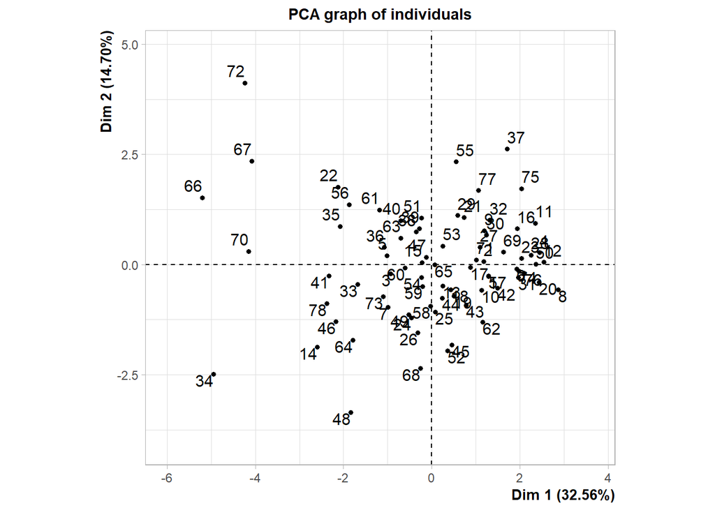

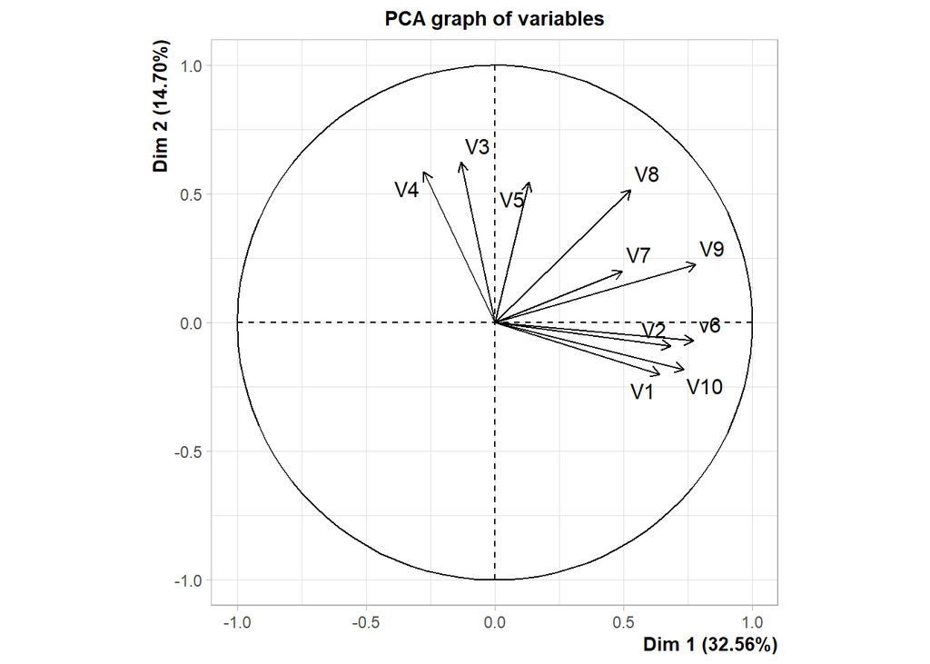

```r
res.pca <- PCA(AD[c(16:20,21:25)])
```

```r
eig <- get_eigenvalue(res.pca)
eig
```

```
##        eigenvalue variance.percent cumulative.variance.percent
## Dim.1   3.2561176        32.561176                    32.56118
## Dim.2   1.4702458        14.702458                    47.26363
## Dim.3   1.2446974        12.446974                    59.71061
## Dim.4   0.9717957         9.717957                    69.42857
## Dim.5   0.7640383         7.640383                    77.06895
## Dim.6   0.6478073         6.478073                    83.54702
## Dim.7   0.5392968         5.392968                    88.93999
## Dim.8   0.4285364         4.285364                    93.22535
## Dim.9   0.3573743         3.573743                    96.79910
## Dim.10  0.3200905         3.200905                   100.00000
```

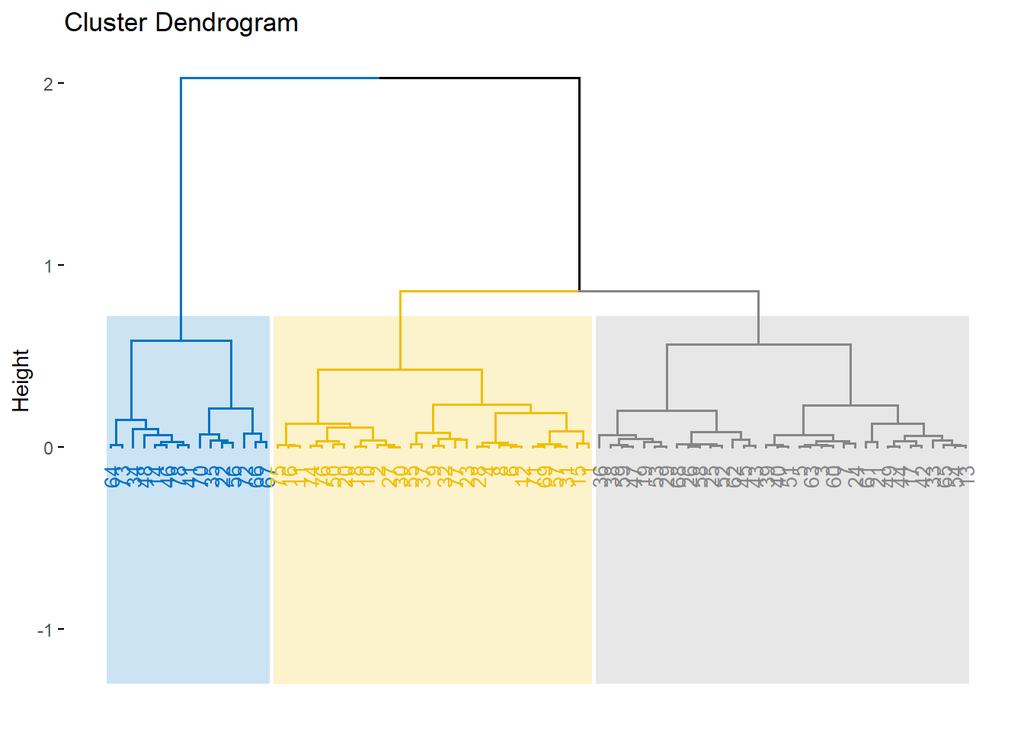

```r
res.hcpc <- HCPC(res.pca, graph = FALSE)
fviz_dend(res.hcpc,
          cex = 0.7,
          palette = "jco",
          rect = TRUE, rect_fill = TRUE,
          rect_border = "jco",
          labels_track_height = 0.8
          )
```

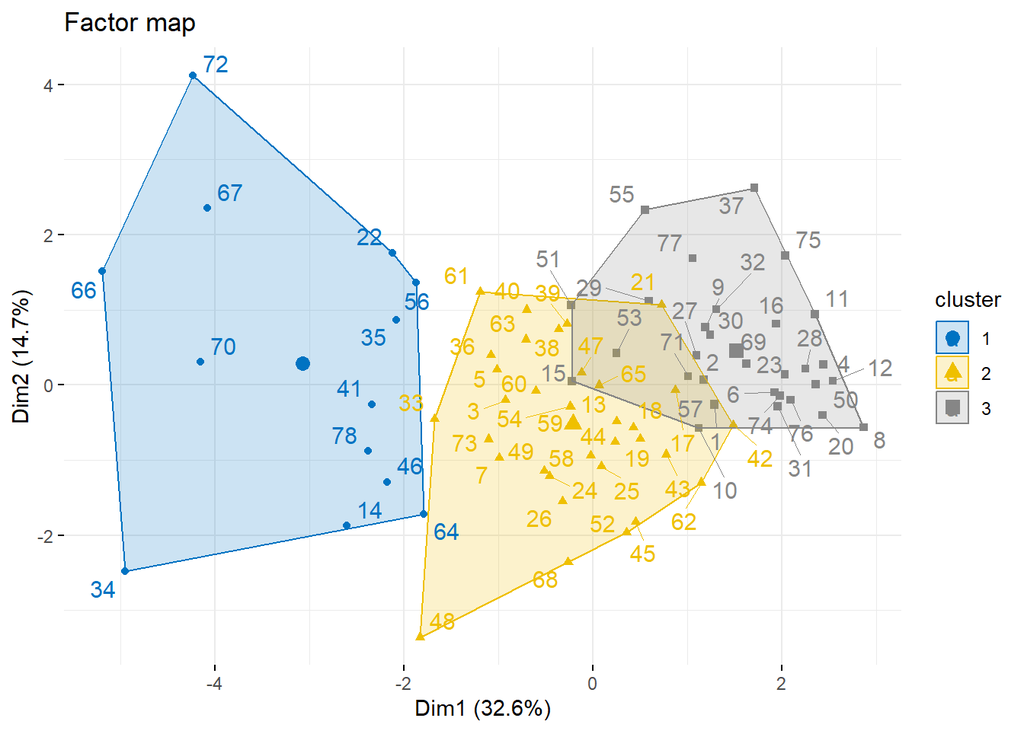

```r
fviz_cluster(res.hcpc,
             repel = TRUE,
             show.clust.cent = TRUE,
             palette = "jco",
             ggtheme = theme_minimal(),
              main = "Factor map"
             )
```

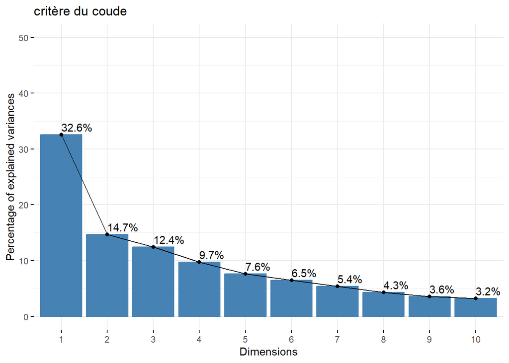

```r
fviz_eig(res.pca,main = "critère du coude", addlabels = TRUE, ylim = c(0, 50))
```

Sur l’éboulis des valeurs propres, on observe un décrochement (coude) suivi d’une décroissance régulière. On sélectionne les axes avant le décrochement. Dans notre cas on retient les deux premiers axes.

```r
var <- get_pca_var(res.pca)
var
```

```
## Principal Component Analysis Results for variables
##  ===================================================
##   Name       Description
## 1 "$coord"   "Coordinates for the variables"
## 2 "$cor"     "Correlations between variables and dimensions"
## 3 "$cos2"    "Cos2 for the variables"
## 4 "$contrib" "contributions of the variables"
```

```r
var$coord
```

```
##          Dim.1       Dim.2       Dim.3       Dim.4        Dim.5
## V1   0.6413293 -0.20016056  0.57431577  0.07503071  0.161156968
## V2   0.6828105 -0.09180042  0.40985250  0.01969779 -0.027398144
## V3  -0.1298367  0.62231198  0.24233921 -0.62427035 -0.045829626
## V4  -0.2748802  0.58473149  0.11582886  0.32754353  0.669103407
## V5   0.1327392  0.54526178  0.41976627  0.47592126 -0.456892776
## v6   0.7711487 -0.07076499 -0.20917893  0.04286089  0.227240027
## V7   0.4954475  0.19960641 -0.57902124  0.36714893 -0.124711739
## V8   0.5287250  0.51599545 -0.33950321 -0.25635947 -0.044614680
## V9   0.7806334  0.22613606 -0.05266066 -0.07624765 -0.009539949
## V10  0.7344866 -0.18171826  0.03839725 -0.18468767  0.097431214
```

La variable V1 est positivement corrélé à la variable V2 , V6 , V9 ,v10. Quand un individu a peur de son avenir et celle de sa famille en Tunisie,il trouve qu’il n’arrivera pas à atteindre ses objectifs financières en Tunisie.Il aspires à un autre style de vie en quittant la Tunisie afin d’avoir un meilleur travail au meme temps IL veut sortir du routine .

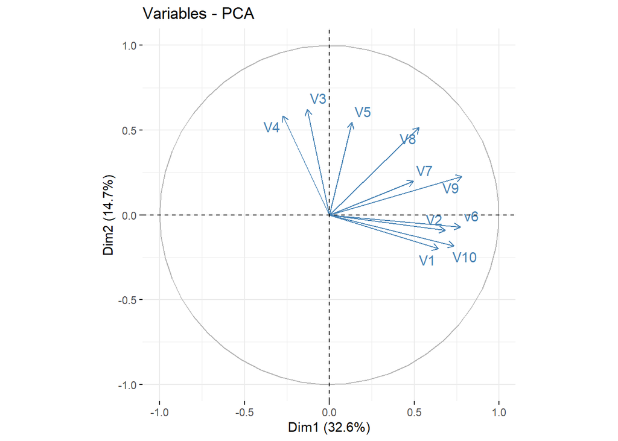

```r
fviz_pca_var(res.pca, col.var = "steelblue",repel = T)
```

La distance entre les variables et l’origine mesure la qualité de représentation des variables. Les variables qui sont loin de l’origine sont bien représentées par l’ACP.

*Qualité de représentation :* La qualité de représentation des variables sur la carte de l’ACP s’appelle cos2 (cosinus carré) . Vous pouvez accéder au cos2 comme suit:

```r
var$cos2
```

```
##          Dim.1       Dim.2       Dim.3        Dim.4        Dim.5
## V1  0.41130325 0.040064249 0.329838608 0.0056296074 2.597157e-02
## V2  0.46623018 0.008427317 0.167979072 0.0003880028 7.506583e-04
## V3  0.01685757 0.387272196 0.058728291 0.3897134761 2.100355e-03
## V4  0.07555915 0.341910911 0.013416324 0.1072847623 4.476994e-01
## V5  0.01761968 0.297310407 0.176203723 0.2265010418 2.087510e-01
## v6  0.59467034 0.005007683 0.043755824 0.0018370557 5.163803e-02
## V7  0.24546826 0.039842718 0.335265599 0.1347983399 1.555302e-02
## V8  0.27955012 0.266251307 0.115262431 0.0657201789 1.990470e-03
## V9  0.60938847 0.051137519 0.002773145 0.0058137034 9.101064e-05
## V10 0.53947062 0.033021528 0.001474349 0.0341095355 9.492842e-03
```

La fonction corrpolt génére le corrgram donné ci-dessous qui permet d’étudier les corrélations entre les différnetes variables quantitatives

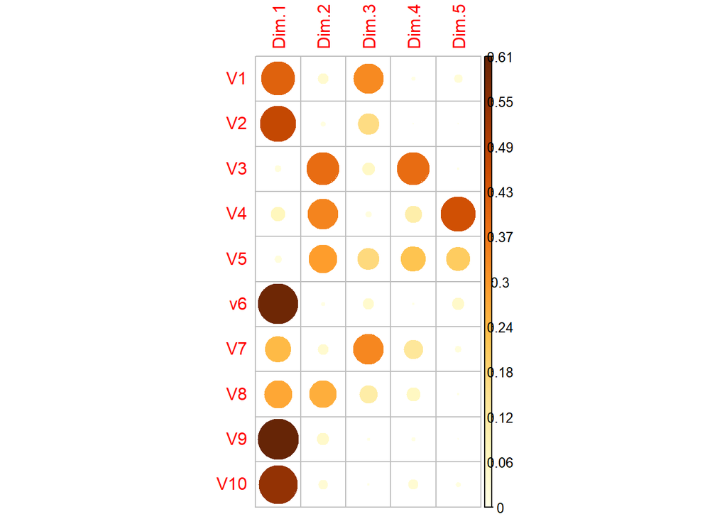

```r
corrplot(var$cos2, is.corr=FALSE)
```

Il est clair qu’il existe des corrélations importantes entre des groupes de variables ce qui suggère la pertinence de cette ACP .

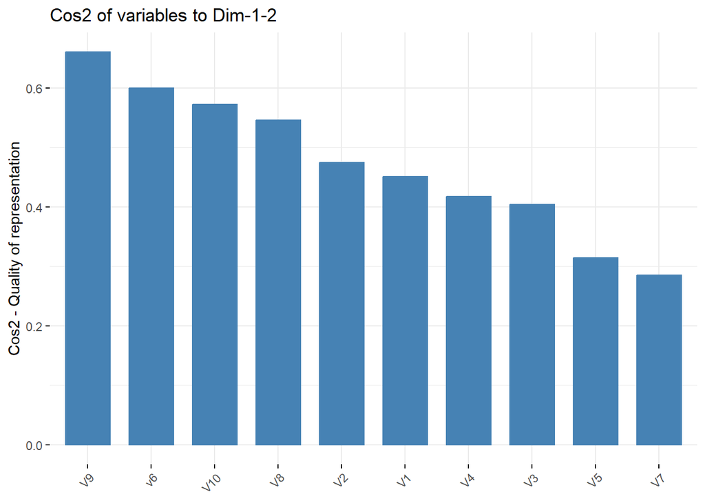

```r
fviz_cos2(res.pca, choice = "var", axes = 1:2)
```

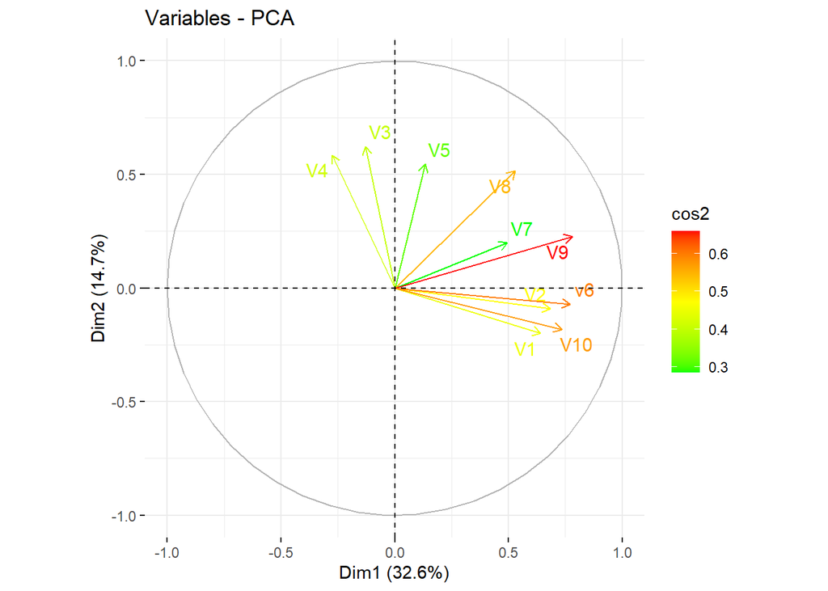

```r
fviz_pca_var(res.pca, col.var = "cos2",
gradient.cols = c("green", "yellow", "red"),
repel = TRUE)
```

les variables à faible valeur de cos2 sont colorées en “green” (vert) • les variables avec les valeurs moyennes de cos2 sont colorées en “yellow” (bleu) • les variables avec des valeurs élevées de cos2 sont colorées en “red” (rouge).

## Contributions des variables aux axes principaux :

Les contributions des variables dans la définition d’un axe principal donné, sont exprimées en pourcentage. • Les variables corrélées avec PC1 (i.e., Dim.1) et PC2 (i.e., Dim.2) sont les plus importantes pour expliquer la variabilité dans le jeu de données. • Les variables qui ne sont pas en corrélation avec un axe ou qui sont corrélées avec les derniers axes sont des variables à faible apport et peuvent être supprimées pour simplifier l’analyse globale. La contribution des variables peut être extraite comme suit:

```r
var$contrib
```

```
##          Dim.1      Dim.2      Dim.3       Dim.4       Dim.5
## V1  12.6317073  2.7250034 26.4995023  0.57929948  3.39924941
## V2  14.3185913  0.5731910 13.4955754  0.03992637  0.09824877
## V3   0.5177199 26.3406423  4.7182787 40.10240780  0.27490174
## V4   2.3205287 23.2553565  1.0778784 11.03984735 58.59645419
## V5   0.5411255 20.2218160 14.1563506 23.30747511 27.32205974
## v6  18.2631711  0.3406018  3.5153786  0.18903723  6.75856536
## V7   7.5386791  2.7099358 26.9355113 13.87105740  2.03563319
## V8   8.5853815 18.1093053  9.2602776  6.76275668  0.26051961
## V9  18.7151860  3.4781611  0.2227968  0.59824338  0.01191179
## V10 16.5679095  2.2459868  0.1184504  3.50994919  1.24245620
```

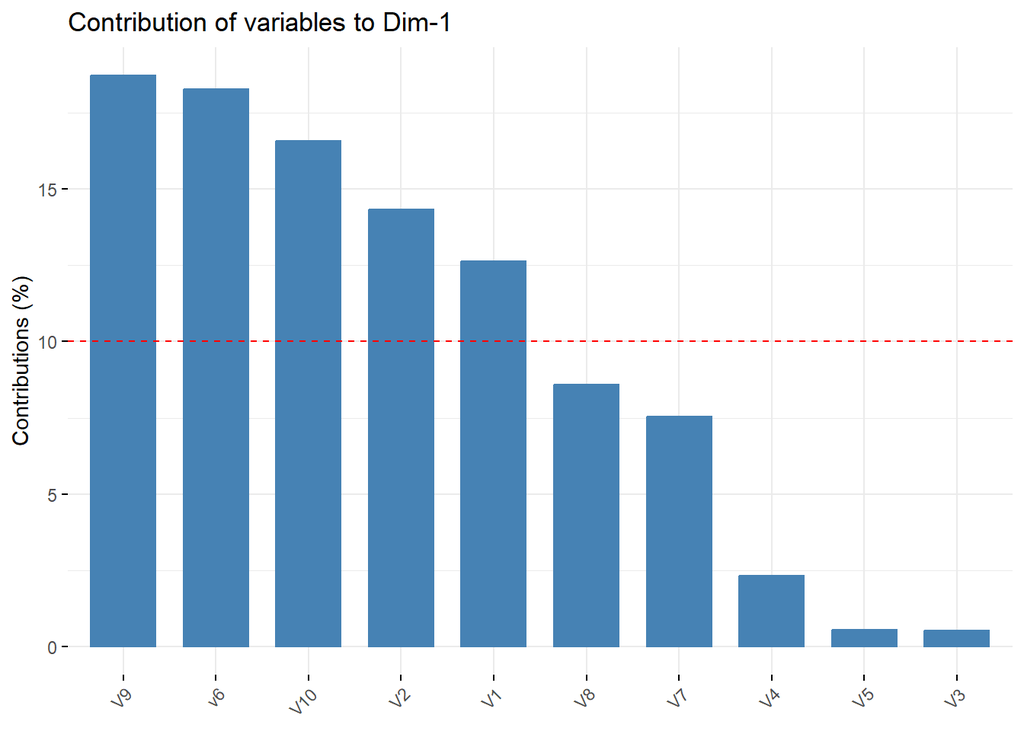

```r
fviz_contrib(res.pca, choice = "var", axes = 1, top = 14)
```

Les variables V1,V2,V6,V9,V10 sur le seuil donc elles contribuent dans la construction du premier axe

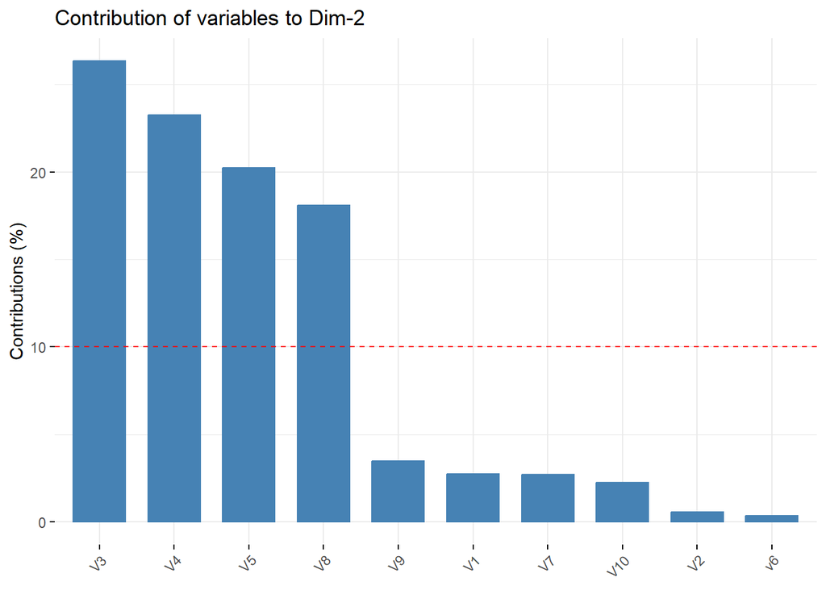

```r
fviz_contrib(res.pca, choice = "var", axes = 2, top = 14)
```

La ligne en pointillé rouge, sur le graphique ci-dessus, indique la contribution moyenne attendue. Si la contribution des variables était uniforme, la valeur attendue serait 1/length(variables) = 1/10 = 10%. Pour une composante donnée, une variable avec une contribution supérieure à ce seuil pourrait être considérée comme importante pour contribuer à la composante.

## Description des dimensions :

Dans les sections précédentes, nous avons décrit comment mettre en évidence les variables en fonction de leurs contributions aux composantes principales. la fonction dimdesc() [dans FactoMineR], pour dimension description (en anglais), peut être utilisée pour identifier les variables les plus significativement associées avec une composante principale donnée Elle peut être utilisée comme suit:

```r
res.desc <- dimdesc(res.pca, axes = c(1,2), proba = 0.05)

res.desc$Dim.1
```

```
##
## Link between the variable and the continuous variables (R-square)
## =================================================================================
##     correlation      p.value
## V9    0.7806334 3.551971e-17
## v6    0.7711487 1.465438e-16
## V10   0.7344866 1.964566e-14
## V2    0.6828105 5.742426e-12
## V1    0.6413293 2.519208e-10
## V8    0.5287250 6.493395e-07
## V7    0.4954475 3.991464e-06
## V4   -0.2748802 1.486721e-02
```

Le 1er axe est fortement corrélé positivement avec les items V9 ,V6 ,V10,v2,V1 (Corrélé positivement d’une manière moins importante avec les autres ) Si on devait donner un nom à cet axe serait l’axe ” financement ”

```r
res.desc$Dim.2
```

```
##
## Link between the variable and the continuous variables (R-square)
## =================================================================================
##    correlation      p.value
## V3   0.6223120 1.185366e-09
## V4   0.5847315 1.895951e-08
## V5   0.5452618 2.444590e-07
## V8   0.5159955 1.330610e-06
## V9   0.2261361 4.650239e-02
```

## Interprétation de la carte des individus :

Les résultats, pour les individus, peuvent être extraits à l’aide de la fonction get_pca_ind() [package factoextra].

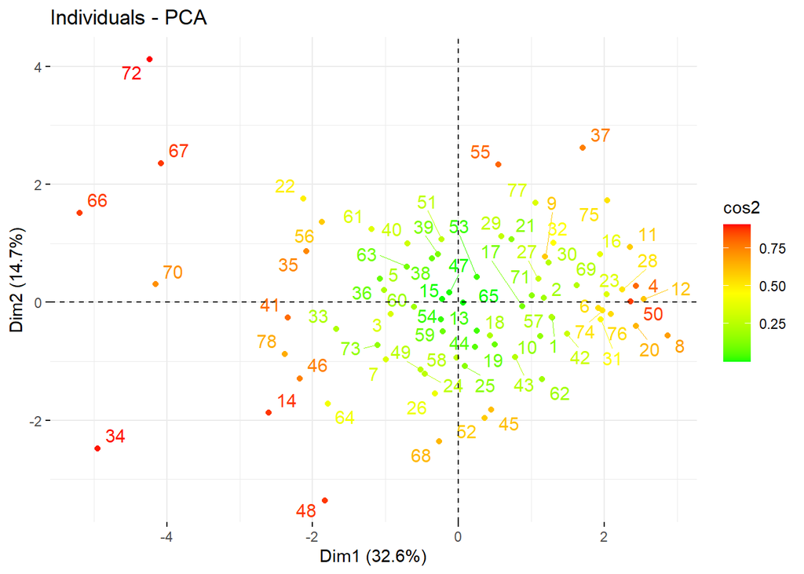

```r
ind <- get_pca_ind(res.pca)
fviz_pca_ind (res.pca, col.ind = "cos2",
gradient.cols = c("green", "yellow", "red"),
repel = TRUE
)
```

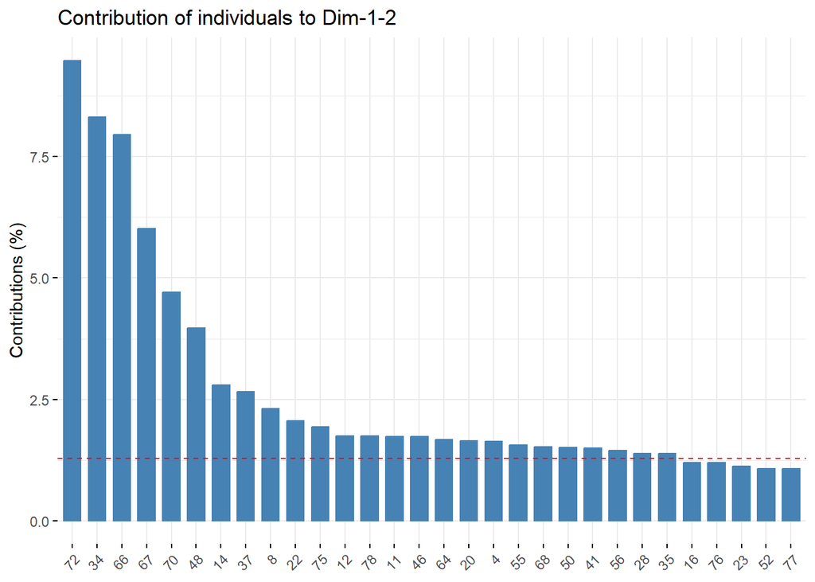

```r
fviz_contrib(res.pca, choice = "ind", axes = 1:2, top=30)
```

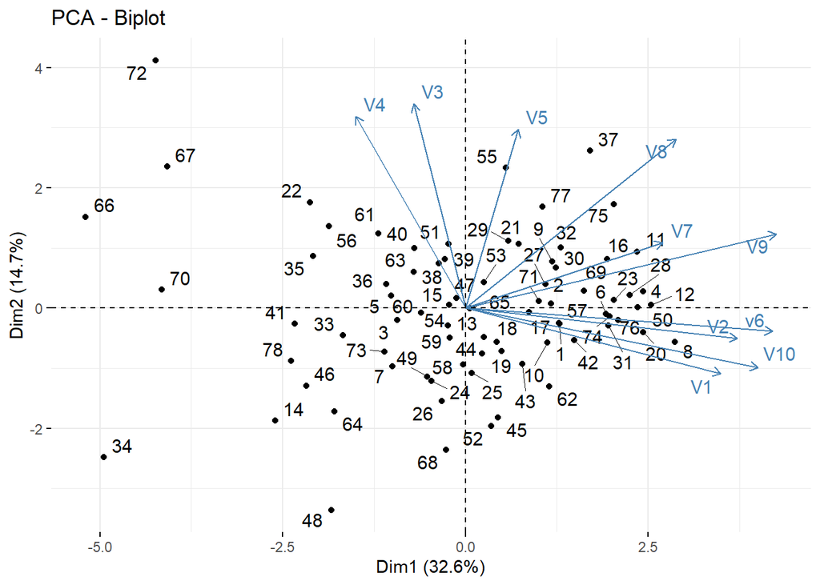

```r
fviz_pca_biplot(res.pca, repel=T)
```

# Analyse Factorielle des Correspondances sur la décision de migration et la catégorie socio-professionnelle :

Tableau croisé des effectifs :

```r
tafc<-table(AD$VS1,AD$"Envisagez-vous de quitter la Tunisie un jour ?" )
tafc
```

```
##
##                   Aucune idée non oui
##   chômeur                   0   1   3
##   fonctionnaire             0   3   1
##   étudiant                 12   5  47
##   cadre supérieur           0   1   2
##   retraité                  0   3   0
```

```r
addmargins(tafc)
```

```
##
##                   Aucune idée non oui Sum
##   chômeur                   0   1   3   4
##   fonctionnaire             0   3   1   4
##   étudiant                 12   5  47  64
##   cadre supérieur           0   1   2   3
##   retraité                  0   3   0   3
##   Sum                      12  13  53  78
```

Tableaux des profils-lignes et profils-colonnes :

```r
lprop(tafc)
```

```
##
##                   Aucune idée non   oui   Total
##   chômeur           0.0        25.0  75.0 100.0
##   fonctionnaire     0.0        75.0  25.0 100.0
##   étudiant         18.8         7.8  73.4 100.0
##   cadre supérieur   0.0        33.3  66.7 100.0
##   retraité          0.0       100.0   0.0 100.0
##   All              15.4        16.7  67.9 100.0
```

```r
cprop(tafc)
```

```
##
##                   Aucune idée non   oui   All
##   chômeur           0.0         7.7   5.7   5.1
##   fonctionnaire     0.0        23.1   1.9   5.1
##   étudiant        100.0        38.5  88.7  82.1
##   cadre supérieur   0.0         7.7   3.8   3.8
##   retraité          0.0        23.1   0.0   3.8
##   Total           100.0       100.0 100.0 100.0
```

Ainsi , on a parmi ceux qui ont choisis non 38.5% sont des étudiants , 23.1 % d’eux sont des fonctionnaires , 23.1% sont des retraités , 23,1% des retraités et 7.7 % des chomeurs .

## Test du chi-2 :

```r
khit<-chisq.test(tafc)
khit
```

```
##
##  Pearson's Chi-squared test
##
## data:  tafc
## X-squared = 30.407, df = 8, p-value = 0.0001791
```

Le degré de liberté du χ2 est de (p−1)∗(q−1)=(5−1)∗(3−1)= 8

La p-value étant presque nulle (elle est de l’ordre de 10 puissance -4), on peut donc rejeter l’hypothèse d’indépendance : l’AFC est donc pertinente Exécution de l’AFC :

```r
res.ca<-CA(tafc,graph=F)
summary(res.ca)
```

```
##
## Call:
## CA(X = tafc, graph = F)
##
## The chi square of independence between the two variables is equal to 30.40684 (p-value =  0.0001790785 ).
##
## Eigenvalues
##                        Dim.1   Dim.2
## Variance               0.377   0.013
## % of var.             96.729   3.271
## Cumulative % of var.  96.729 100.000
##
## Rows
##                   Iner*1000     Dim.1     ctr    cos2     Dim.2     ctr    cos2
## chômeur         |    10.402 |   0.256   0.889   0.322 |  -0.371  55.304   0.678
## fonctionnaire   |   126.512 |   1.571  33.550   1.000 |   0.001   0.001   0.000
## étudiant        |    48.273 |  -0.241  12.622   0.986 |   0.029   5.327   0.014
## cadre supérieur |    12.337 |   0.475   2.299   0.703 |  -0.309  28.760   0.297
## retraité        |   192.308 |   2.228  50.640   0.993 |   0.188  10.608   0.007
##
## chômeur         |
## fonctionnaire   |
## étudiant        |
## cadre supérieur |
## retraité        |
##
## Columns
##                   Iner*1000     Dim.1     ctr    cos2     Dim.2     ctr    cos2
## Aucune idée     |    33.654 |  -0.392   6.276   0.703 |   0.255  78.339   0.297
## non             |   312.099 |   1.368  82.747   1.000 |   0.021   0.586   0.000
## oui             |    44.078 |  -0.247  10.977   0.939 |  -0.063  21.075   0.061
##
## Aucune idée     |
## non             |
## oui             |
```

## Choix du nombre d’axes à retenir :

```r
eig.val <- res.ca$eig

round(res.ca$eig,3)
```

```
##       eigenvalue percentage of variance cumulative percentage of variance
## dim 1      0.377                 96.729                            96.729
## dim 2      0.013                  3.271                           100.000
```

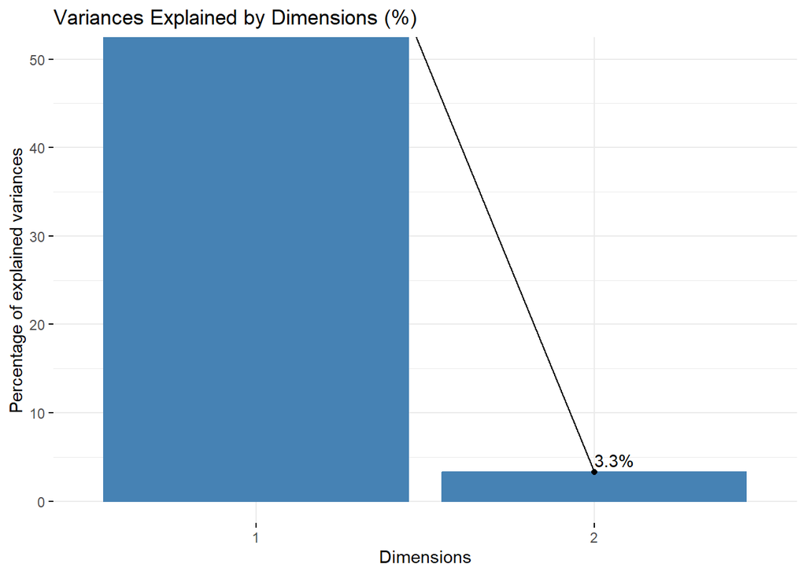

```r
fviz_eig(res.ca, main = "Variances Explained by Dimensions (%)",addlabels = TRUE, ylim = c(0, 50))
```

## Représentation et interprétation de la carte des profils-colonnes

```r
round(cbind(res.ca$col$coord[,1:2],res.ca$col$contrib[,1:2], res.ca$col$cos2[,1:2]),2)
```

```
##             Dim 1 Dim 2 Dim 1 Dim 2 Dim 1 Dim 2
## Aucune idée -0.39  0.25  6.28 78.34  0.70  0.30
## non          1.37  0.02 82.75  0.59  1.00  0.00
## oui         -0.25 -0.06 10.98 21.07  0.94  0.06
```

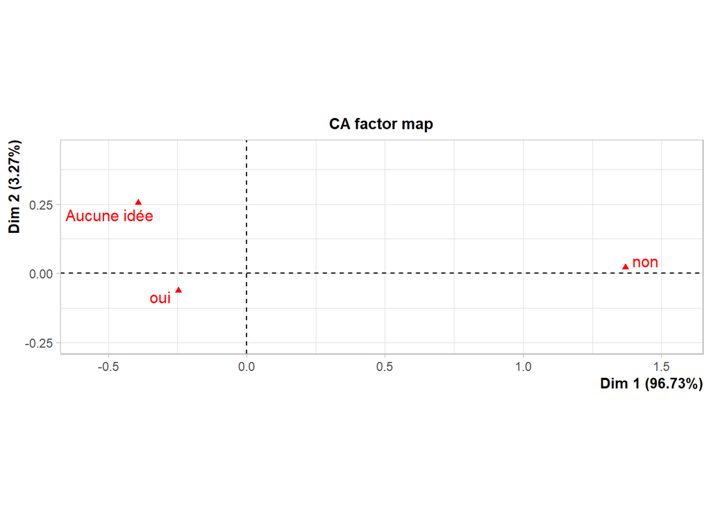

```r
plot(res.ca, invisible="row")
```

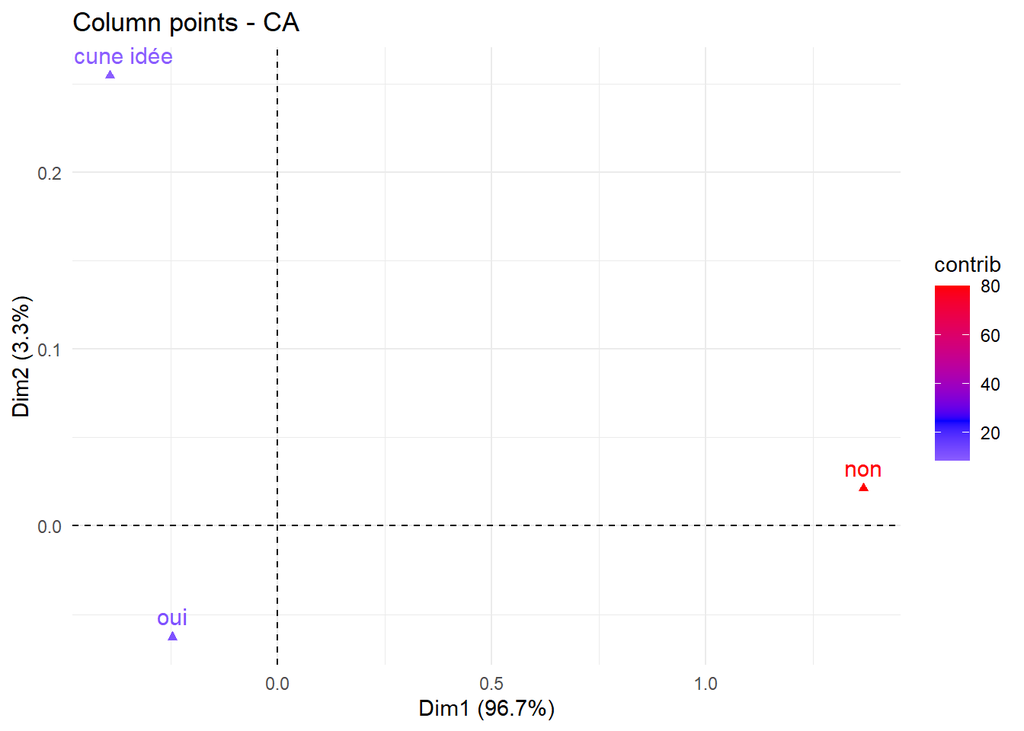

```r
fviz_ca_col(res.ca, col.col = "contrib")+
scale_color_gradient2(low = "white", mid = "blue",
high = "red", midpoint = 25) +
theme_minimal()
```

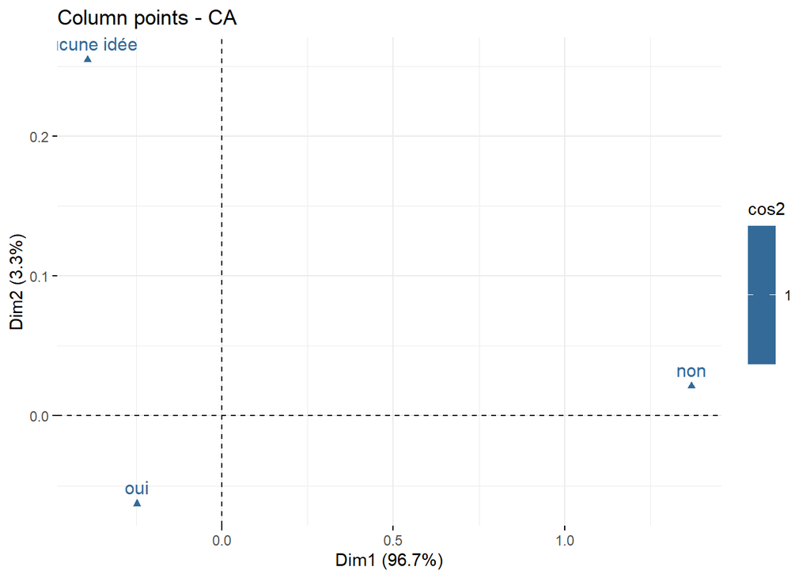

```r
fviz_ca_col(res.ca, col.col="cos2")
```

## Représentation et interprétation de la carte des profils-lignes :

```r
round(cbind(res.ca$row$coord[,1:2],res.ca$row$contrib[,1:2], res.ca$row$cos2[,1:2]),2)
```

```
##                 Dim 1 Dim 2 Dim 1 Dim 2 Dim 1 Dim 2
## chômeur          0.26 -0.37  0.89 55.30  0.32  0.68
## fonctionnaire    1.57  0.00 33.55  0.00  1.00  0.00
## étudiant        -0.24  0.03 12.62  5.33  0.99  0.01
## cadre supérieur  0.47 -0.31  2.30 28.76  0.70  0.30
## retraité         2.23  0.19 50.64 10.61  0.99  0.01
```

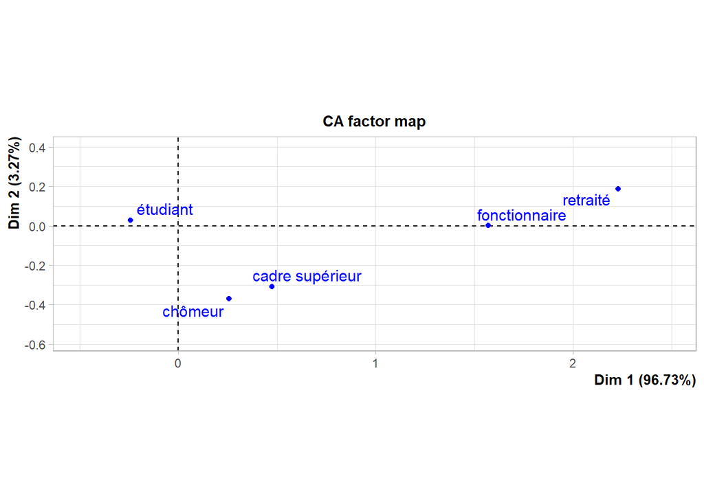

```r
plot(res.ca, invisible="col")
```

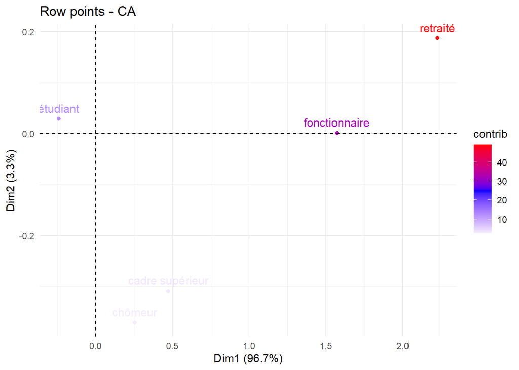

```r
fviz_ca_row(res.ca, col.row = "contrib")+
scale_color_gradient2(low = "white", mid = "blue",
high = "red", midpoint = 25) +
theme_minimal()
```

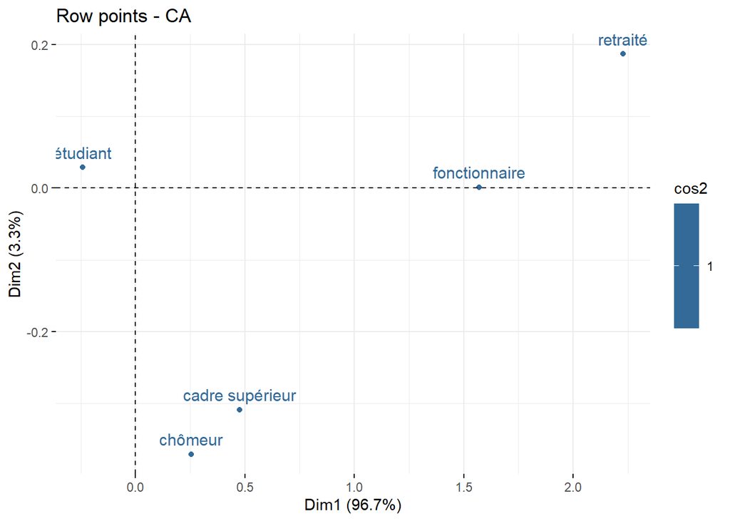

```r
fviz_ca_row(res.ca, col.row = "cos2")
```

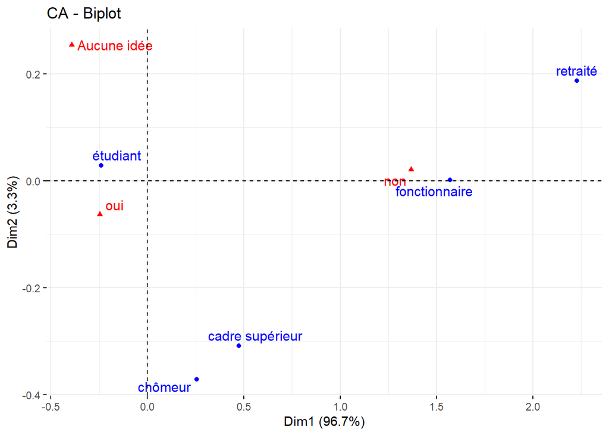

```r
fviz_ca_biplot(res.ca, repel=T)
```

Le lien entre ’non ‘ et fonctionnaire est quasiment “symétrique” (presque confondue). . On peut facilement s’en rendre compte en consultant les profils de chacune des ces 2 modalités puisque parmi ceux qui ont voté non on a 23.1% des individus sont des fonctionnaires .